# Reproducible Research: Peer Assessment 1

The aim of this assignment is to analyse data from a personal activity monitoring device. So, first of all it is needed to download the data into an R object ready to be analysed. Here the code:

## Loading and preprocessing the data

```r
        data <- read.csv("activity/activity.csv", colClasses = "character")
        data[, c(1,3)] <- sapply(data[, c(1,3)], as.numeric)
```

## What is mean total number of steps taken per day?

To answer this question the overall number of steps taken per day has been calculated . Here the analysis code:

1. A data set containing the sum of the number of steps taken each day is created.

```r
        dailyStepSum <- aggregate(data$steps, list(data$date), sum)
        colnames(dailyStepSum) <- c("Date", "Steps")
```

2. Then, to visualize the information a barplot is created:

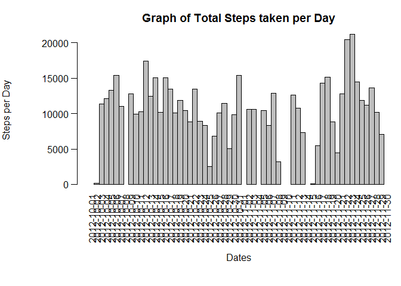

```r
        with(dailyStepSum, {
        par(oma=c(2,0,0,0), mar=c(6.75,6.75,3,0), mgp=c(5.75,0.75,0), las=2)
        barplot(
        height=Steps,
        main="Graph of Total Steps taken per Day",
        xlab="Dates",
        ylab="Steps per Day",
        names.arg=Date,
        space=c(0)
        )
        })
```

3. Finally to answer the question the media and the median has been calculated ignoring the missing values (NA).

```r
        dailyStepMean <- mean(dailyStepSum$Steps, na.rm = TRUE)
        dailyStepMean
```

```
## [1] 10766.19
```

```r
        dailyStepMedian <- median(dailyStepSum$Steps, na.rm = TRUE)
        dailyStepMedian
```

```
## [1] 10765
```

## What is the average daily activity pattern?

The goal of this section is to calculate the mean of the steps taken every 5 minutes interval averaged over all the days in the observation periode. Then the data sample has been aggregate in a slightly different way than before, by intervals. Here the code:

```r
         intervalSteps <- aggregate(data=data,steps~interval,FUN=mean,na.action=na.omit)
         colnames(intervalSteps) <- c("Interval", "AvgStepsAvgAcrossDay")
```

1. A time series plot is created with the new dataset:

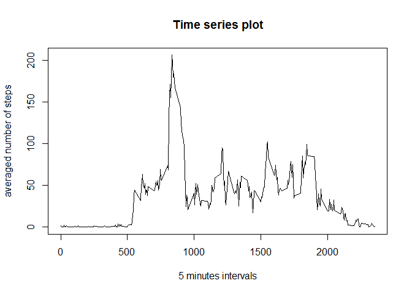

```r
        plot(intervalSteps$Interval, intervalSteps$AvgStepsAvgAcrossDay,ylab ="averaged number of steps", xlab="5 minutes intervals", type="l", main = "Time series plot")
```

2. The interval (bin) with the maximum number of steps has been calculated:

```r
        maxbin <- intervalSteps[intervalSteps$AvgStepsAvgAcrossDay == max(intervalSteps$AvgStepsAvgAcrossDay),]
        maxbin
```

```
##     Interval AvgStepsAvgAcrossDay
## 104      835             206.1698
```